# Aprendizaje Estadístico y Toma de Decisiones II

Tarea 3

Juan José Martín Miralles

```r
library(ggplot2)
library(reshape2)
library(neuralnet)
```

**Model a binary to decimal decoder.**

| $x_1$ | $x_2$ | $x_3$ | $d$ |
| --- | --- | --- | --- |
| 0 | 0 | 1 | 1 |
| 0 | 1 | 0 | 2 |
| 0 | 1 | 1 | 3 |
| 1 | 0 | 0 | 4 |
| 1 | 0 | 1 | 5 |
| 1 | 1 | 0 | 6 |
| 1 | 1 | 1 | 7 |

**Given the training set provided, using Adaline, find the weights that minimize the error (SSE). Give final weights and error. Train for different values of the parameters.**

Creamos un dataframe con los datos de la tabla del enunciado.

```r
x1 = c(0, 0, 0, 1, 1, 1, 1)
x2 = c(0, 1, 1, 0, 0, 1, 1)
x3 = c(1, 0, 1, 0, 1, 0, 1)
d = c(1, 2, 3, 4, 5, 6, 7)
df = data.frame(x1, x2, x3, d)
```

La función siguiente es la implementación del tipo de red neuronal artificial **Adaline** con *Gradient Descent*.

```r
adalineGD = function(X, d, n_iter=10, eta=0.01) {
  X[, dim(X)[2] + 1] = 1
  X = as.matrix(X)
  w = as.matrix(rep(0, dim(X)[2]))

  cost = rep(0, n_iter)
  error = rep(0, n_iter)

  # loop over the number of epochs
  for (i in 1:n_iter) {
    # find the number of wrong prediction before weight update
    for (j in 1:dim(X)[1]) {
      # compute net input
      z = sum(w * X[j, ])
      ypred = round(z)

      # comparison with actual labels and counting error
      if(ypred != d[j]) {
        error[i] = error[i] + 1
      }
    }
    cost[i] = sum((d - X %*% w)^2)/2

    # update weight according to gradient descent
    w = w + eta*t(X) %*% (d - X %*% w)
  }

  infomatrix = matrix(rep(0, 3 * n_iter), nrow = n_iter, ncol = 3)
  infomatrix[, 1] = 1:n_iter
  infomatrix[, 2] = round(cost, 3)
  infomatrix[, 3] = error

  infodf = as.data.frame(infomatrix)
  names(infodf) = c("epoch", "cost", "error")

  return(infodf)
}
```

A continuación, separamos los predictores de la variable independiente, y normalizamos y estandarizamos los predictores.

```r
X = df[, 1:3]
y = df[,4]

normalize.bipolar = function(v){
  return((v - min(v)) / (max(v) - min(v)) * (1 - (-1)) + (-1))
}
X_norm = as.data.frame(lapply(X, normalize.bipolar))

standardize = function(x) {
  return((x - mean(x)) / (sd(x)))
}
X_std = as.data.frame(lapply(X, standardize))
```

Por último, usamos la función de **Adaline** con los datos originales, estandarizados y normalizados para $eta = 0.1$, $eta = 0.01$ y $eta = 0.001$.

```r
eta = c(0.1, 0.01, 0.001)
n_iter = 40

result_orig = c()
result_std = c()
result_norm = c()

for(i in 1:length(eta)) {
  ada_orig = adalineGD(X, y, n_iter, eta[i])
  label = rep("original", dim(ada_orig)[1])
  result_orig[[i]] = cbind(label, ada_orig)

  ada_std = adalineGD(X_std, y, n_iter, eta[i])
  label = rep("standard", dim(ada_std)[1])
  result_std[[i]] = cbind(label, ada_std)

  ada_norm = adalineGD(X_norm, y, n_iter, eta[i])
  label = rep("normalize", dim(ada_norm)[1])
  result_norm[[i]] = cbind(label, ada_norm)
}
```

Y por último, visualizamos los resultados.

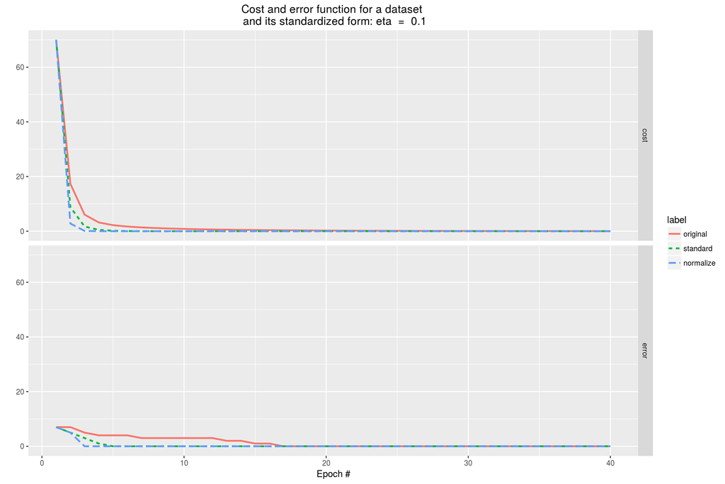

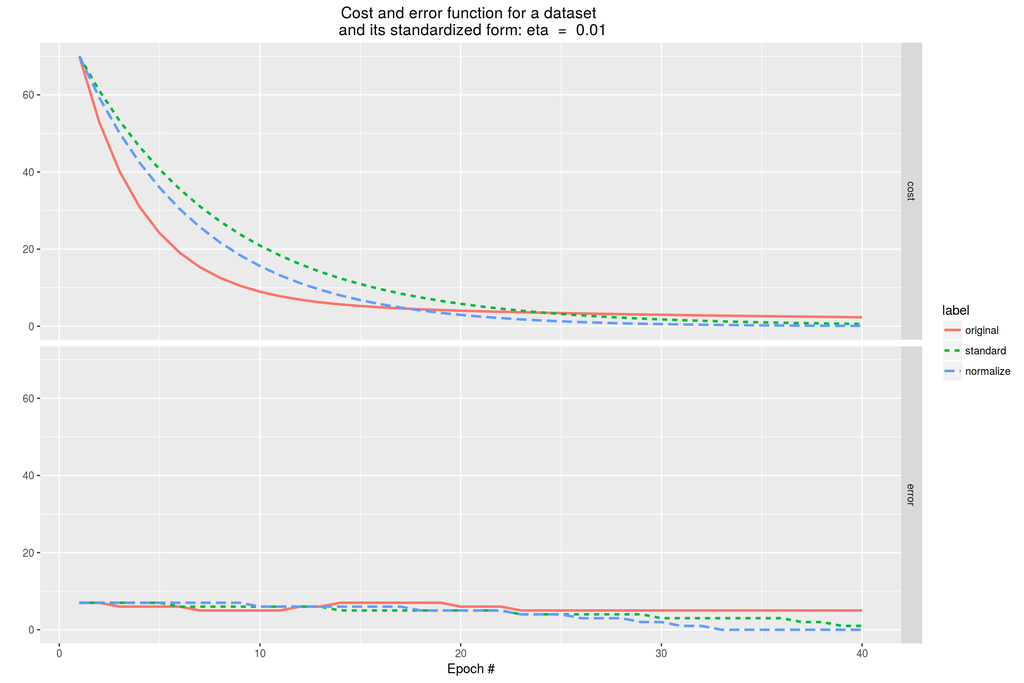

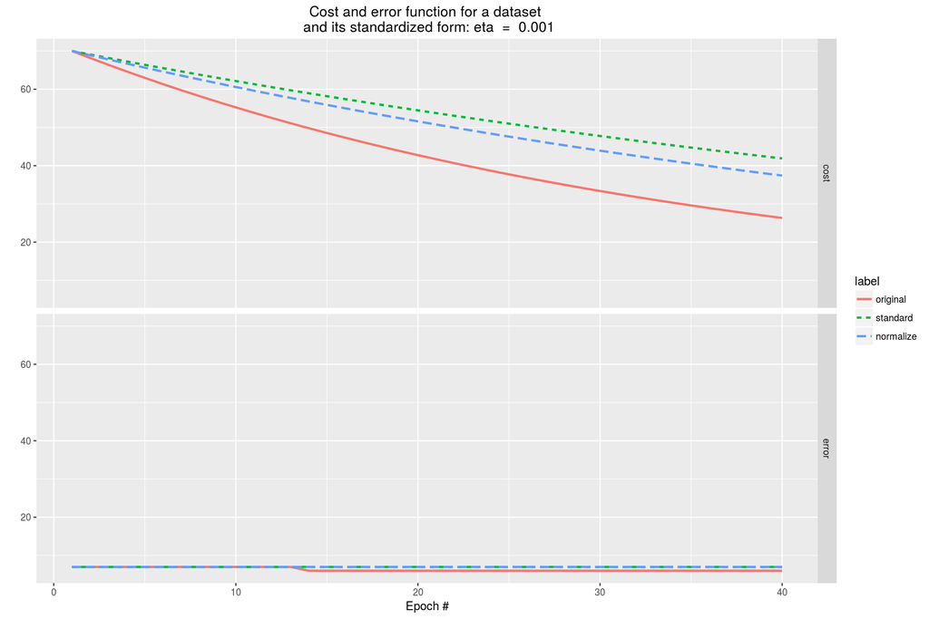

```r
for(i in 1:length(eta)) {
  title = paste("Cost and error function for a dataset \n and its standardized form: eta", " = ", eta[i])

  adaline_models = rbind(result_orig[[i]], result_std[[i]], result_norm[[i]])
  df_adaline = melt(adaline_models, id.vars=c("epoch", "label"))

  gg = ggplot(df_adaline, aes(x=epoch, y=value)) +
    geom_line(aes(color=label, linetype=label), size = 1) +
    facet_grid(variable ~ .) + xlab("Epoch #") + ylab("") +
    ggtitle(title) +
    theme(plot.title = element_text(hjust = 0.5))
  print(gg)
}
```

Podemos observar que con un $eta = 0.1$ la función converge más rápidamente y, por lo tanto, es capaz de resolver todos los registros correctamente en una menor cantidad de pasos. Además, con los datos normalizados es de la manera con la que ha ido mejor, dado que ha realizado un menor número de iteraciones

**Given the training set provided, find a multilayer perceptron that models the data. Give final weights and error. Train for different values of the parameters.**

```r
hidden_layers = c(2, 3, 4, 5, 6)
threshold = c(0.1, 0.01, 0.001)

# Original
for(h in hidden_layers) {
  for(t in threshold) {
    neu_net_orig = neuralnet(y ~ X[[1]] + X[[2]] + X[[3]], X, hidden = h, lifesign = "minimal", linear.output = TRUE, threshold = t)
  }
}
```

```
## hidden: 2    thresh: 0.1    rep: 1/1    steps:      65   error: 0.0215   time: 0.01 secs
## hidden: 2    thresh: 0.01    rep: 1/1    steps:     404  error: 0.00154  time: 0.03 secs
## hidden: 2    thresh: 0.001    rep: 1/1    steps:     569 error: 0.00002  time: 0.04 secs
## hidden: 3    thresh: 0.1    rep: 1/1    steps:      58   error: 0.03815  time: 0.01 secs
## hidden: 3    thresh: 0.01    rep: 1/1    steps:     101  error: 0.00229  time: 0.01 secs
## hidden: 3    thresh: 0.001    rep: 1/1    steps:    1047 error: 0.00011  time: 0.08 secs
## hidden: 4    thresh: 0.1    rep: 1/1    steps:      57   error: 0.02013  time: 0 secs
## hidden: 4    thresh: 0.01    rep: 1/1    steps:     105  error: 0.00092  time: 0.01 secs
## hidden: 4    thresh: 0.001    rep: 1/1    steps:     160 error: 0        time: 0.01 secs
## hidden: 5    thresh: 0.1    rep: 1/1    steps:      30   error: 0.03601  time: 0 secs
## hidden: 5    thresh: 0.01    rep: 1/1    steps:      85  error: 0.00093  time: 0.01 secs
## hidden: 5    thresh: 0.001    rep: 1/1    steps:     227 error: 0        time: 0.02 secs
## hidden: 6    thresh: 0.1    rep: 1/1    steps:      44   error: 0.05338  time: 0.01 secs
## hidden: 6    thresh: 0.01    rep: 1/1    steps:     104  error: 0.00168  time: 0.01 secs
## hidden: 6    thresh: 0.001    rep: 1/1    steps:     167 error: 0        time: 0.02 secs
```

```r
# Standardized
for(h in hidden_layers) {
  for(t in threshold) {
    neu_net_std = neuralnet(y ~ X_std[[1]] + X_std[[2]] + X_std[[3]], X_std, hidden = h, lifesign = "minimal", linear.output = TRUE, threshold = t)
  }
}
```

```
## hidden: 2    thresh: 0.1    rep: 1/1    steps:      63   error: 0.22294  time: 0.01 secs
## hidden: 2    thresh: 0.01    rep: 1/1    steps:     109  error: 0.00034  time: 0.01 secs
## hidden: 2    thresh: 0.001    rep: 1/1    steps:     260 error: 0.00003  time: 0.02 secs
## hidden: 3    thresh: 0.1    rep: 1/1    steps:      26   error: 0.01384  time: 0 secs
## hidden: 3    thresh: 0.01    rep: 1/1    steps:      84  error: 0.0006   time: 0.01 secs
## hidden: 3    thresh: 0.001    rep: 1/1    steps:     154 error: 0        time: 0.02 secs
## hidden: 4    thresh: 0.1    rep: 1/1    steps:      33   error: 0.04901  time: 0 secs
## hidden: 4    thresh: 0.01    rep: 1/1    steps:      51  error: 0.00064  time: 0 secs
## hidden: 4    thresh: 0.001    rep: 1/1    steps:     114 error: 0        time: 0.01 secs
## hidden: 5    thresh: 0.1    rep: 1/1    steps:      30   error: 0.01215  time: 0 secs
## hidden: 5    thresh: 0.01    rep: 1/1    steps:      47  error: 0.00029  time: 0 secs
## hidden: 5    thresh: 0.001    rep: 1/1    steps:      66 error: 0.00001  time: 0.01 secs
## hidden: 6    thresh: 0.1    rep: 1/1    steps:      23   error: 0.0174   time: 0 secs
## hidden: 6    thresh: 0.01    rep: 1/1    steps:      38  error: 0.00019  time: 0 secs
## hidden: 6    thresh: 0.001    rep: 1/1    steps:      72 error: 0        time: 0.01 secs
```

```r
# Normalized
for(h in hidden_layers) {
  for(t in threshold) {
    neu_net_norm = neuralnet(y ~ X_norm[[1]] + X_norm[[2]] + X_norm[[3]], X_norm, hidden = h, lifesign = "minimal", linear.output = TRUE, threshold = t)
  }
}
```

```
## hidden: 2    thresh: 0.1    rep: 1/1    steps:      58   error: 0.0375   time: 0.01 secs
## hidden: 2    thresh: 0.01    rep: 1/1    steps:     169  error: 0.00112  time: 0.01 secs
## hidden: 2    thresh: 0.001    rep: 1/1    steps:     176 error: 0        time: 0.01 secs
## hidden: 3    thresh: 0.1    rep: 1/1    steps:      57   error: 0.02383  time: 0 secs
## hidden: 3    thresh: 0.01    rep: 1/1    steps:      73  error: 0.00063  time: 0.01 secs
## hidden: 3    thresh: 0.001    rep: 1/1    steps:      74 error: 0        time: 0.01 secs
## hidden: 4    thresh: 0.1    rep: 1/1    steps:      25   error: 0.05048  time: 0 secs
## hidden: 4    thresh: 0.01    rep: 1/1    steps:      53  error: 0.00022  time: 0 secs
## hidden: 4    thresh: 0.001    rep: 1/1    steps:     137 error: 0        time: 0.01 secs
## hidden: 5    thresh: 0.1    rep: 1/1    steps:      33   error: 0.02435  time: 0 secs
## hidden: 5    thresh: 0.01    rep: 1/1    steps:      53  error: 0.00025  time: 0.01 secs
## hidden: 5    thresh: 0.001    rep: 1/1    steps:      76 error: 0        time: 0.01 secs
## hidden: 6    thresh: 0.1    rep: 1/1    steps:      21   error: 0.05421  time: 0 secs
## hidden: 6    thresh: 0.01    rep: 1/1    steps:      60  error: 0.00048  time: 0.01 secs
## hidden: 6    thresh: 0.001    rep: 1/1    steps:      51 error: 0        time: 0.01 secs
```

A continuación, mostramos los pesos para la red neuronal con los datos normalizados, 4 neuronas en la capa oculta y un *threshold* de 0.001:

```r
neural = neuralnet(y ~ X_norm[[1]] + X_norm[[2]] + X_norm[[3]], X_norm, hidden = 4,
                   lifesign = "minimal", linear.output = TRUE, threshold = 0.001)
```

```
## hidden: 4    thresh: 0.001    rep: 1/1    steps:      84 error: 0        time: 0.01 secs
```

```r
neural$weights
```

```
## [[1]]
## [[1]][[1]]
##              [,1]         [,2]          [,3]         [,4]
## [1,] -1.138145266 0.2224502363  0.5151548651 -0.800591743
## [2,]  1.348459367 3.7320609567  2.9007713760 -2.216151014
## [3,]  1.566578983 0.8391015387  1.2368009105 -1.226842460
## [4,]  1.205815720 0.1212836534 -0.8713345486  1.099078650
##
## [[1]][[2]]
##               [,1]
## [1,]  1.2249584577
## [2,]  3.3017881271
## [3,]  1.6211610658
## [4,]  1.0655136911
## [5,] -0.4506177244
```

**Which neural network gives the better results?**

Se ha elegido para **Adaline** la red con los datos normalizados y un *threshold* de 0.1, y para *neuralnet* también los datos normalizados, con 4 neuronas en la capa oculta y un *threshold* de 0.001. Estas dos compararemos a continuación.

```r
ada = adalineGD(X_norm, y, 10, 0.1)
ada
```

| epoch | cost | error |
| --- | --- | --- |
| 1 | 70.000 | 7 |
| 2 | 2.800 | 5 |
| 3 | 0.112 | 0 |
| 4 | 0.004 | 0 |
| 5 | 0.000 | 0 |
| 6 | 0.000 | 0 |
| 7 | 0.000 | 0 |
| 8 | 0.000 | 0 |
| 9 | 0.000 | 0 |
| 10 | 0.000 | 0 |

```r
neural = neuralnet(y ~ X_norm[[1]] + X_norm[[2]] + X_norm[[3]], X_norm, hidden = 4,
                   lifesign = "minimal", linear.output = TRUE, threshold = 0.001)
```

```
## hidden: 4    thresh: 0.001    rep: 1/1    steps:     125 error: 0        time: 0.01 secs
```

En este caso **Adaline** ha dado un mejor resultado, ya que en 3 iteraciones a logrado un error de 0, mientras que *neuralnet* ha necesitado muchas más iteraciones para llegar al mismo error. No obstante, el conjunto de datos es demasiado pequeño para dar una valoración rotunda y, por lo tanto, habría que probarlo con un dataset mucho más mayor para poder comparar tiempos, iteraciones y costes.